# Analysis of OTU Data

Fabian Roger

27 Nov 2015

**this script imports:**

- OTU_docs/OTU_clean.txt *cleaned OTU table (only Bacteria)*
- OTU_docs/TAX_clean.txt *cleaned Taxonomic table*
- OTU_docs/OTU97_um.tre *ultrametric tree*
- ID.txt *sample meta-data*

**this script does:**

- some summary statistics
- sensitivity analysis of diversity metrics to rarefaction
- calculates effective number of species
- calculates phylogenetic diversity
- plots heatmaps of dominant OTUs

**this script exports:**

data frames:

- OTU_docs/DIV.txt *effective number of species and phylogenetic diversity based on hill numbers*

figures:

- figures/Figure_2.pdf *heatmap of average abundance of most common OTUs*
- figures/Figure_S_3.pdf *diveristy estimation at different rarefaction*

```r
require(entropart)
require(phyloseq)
require(picante)
require(dplyr)
require(ggplot2)
require(tidyr)
```

Read in the relevant files:

```r
OTU <- read.table("OTU_docs/OTU_clean.txt", sep = "\t", header = TRUE, stringsAsFactors = FALSE)
TAX <- read.table("OTU_docs/TAX_clean.txt", sep = "\t", header = TRUE, stringsAsFactors = FALSE)
TREE <- read.tree("OTU_docs/OTU97_um.tre")
ID <- read.table("ID.txt")

ID$Lake <- factor(ID$Lake, levels = c("Botan", "Delsjön", "Lerum", "Surtesjön"), labels = c("Lake 1", "Lake 2", "Lake 3", "Lake 4"))
```

### seqeuncing depth

Looking at the sequencing depth of the OTU data:

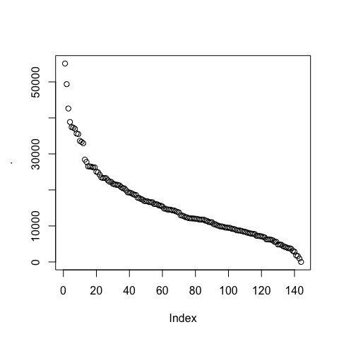

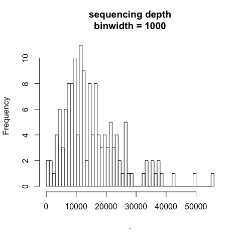

```
##    Min. 1st Qu.  Median    Mean 3rd Qu.    Max.
##      12    8570   12780   15360   20430   55100
```

We can see that the sequencing depth is quite variable and some samples have very low coverage.

```r
colSums(OTU[,-1])[which(colSums(OTU[,-1]) < 1000)]
```

```
## gbg35 gbg12
##   946    12
```

```r
ID[ID$gbgID %in% names(which(colSums(OTU[,-1]) < 1000)), ]
```

```
##    gbgID BOT   Lake Sampling DIL
## 4  gbg12  12 Lake 4    14.06   S
## 29 gbg35  35 Lake 3    14.06  10
```

### sensitivity of diveristy estimation to sequencing depth

We calculate the effective number of species of order 1, corresponding to the exponential of the Shannon entropy. For this test we don’t apply any bias correction.

In an attempt to reduce a possible sampling bias, but without unnecessarily discarding data, we choose the following approach:

- all samples with more than 10000 reads (94 samples) are rarefied to 10000 reads.
- all samples with below 10000 reads (50 samples) are kept as is.
- no correction is applied, because until now it is not clear if correction is accurate for sequencing data (that may contain biased estimates of singletons and doubletons as singletons have been excluded and doubletons may also represent spurious OTUs).
- the above mentioned rules are applied to both estimates, with and without the incorporation of phylogenetic diversity.

### effective number of species

```r
# wrapper function for vegan::rrarefy to rarefy only samples with sequencing depth > S
# assumes samples as columns

rarS <- function(x, S) {
  xR <- rrarefy( t( x[ , colSums( x) > S]), S)
  xR <- t(xR)
  x[, match(colnames(xR), colnames(x))] <- xR
  return(x)
}

OTU_r <- OTU %>%
  select( -gbg12) %>%
  rarS( S = 10000)

MC <-   MetaCommunity(OTU_r)

DIV <- AlphaDiversity(MC, q = 1, Correction="None")$Communities %>%
  data.frame( effN = .) %>%
  add_rownames( var = "gbgID") %>%
  left_join(ID, .)
```

Let’s have a look at the calculated diversity levels:

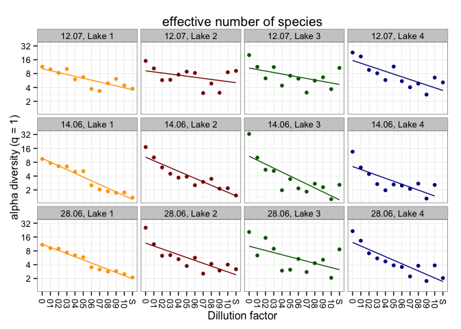

### phylogenetic diveristy

```r
DIV <- AlphaDiversity(MC, q = 1, Tree = TREE, Correction="None")$Communities %>%
  data.frame( PD = .) %>%
  add_rownames( var = "gbgID") %>%
  left_join(DIV, .)
```

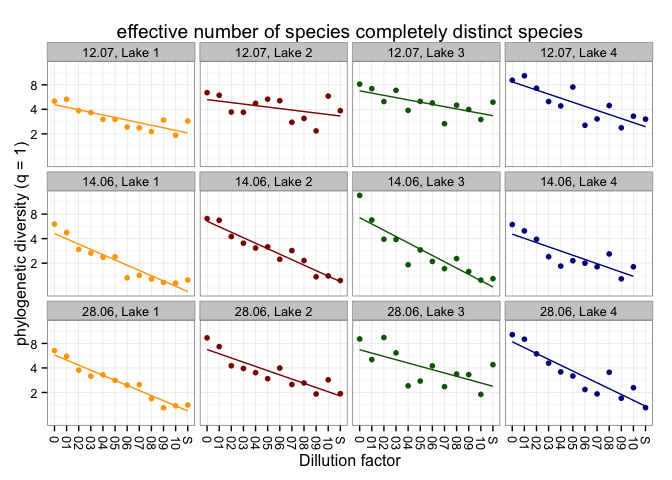

Export table with diversity metrics:

```r
DIV <- select(DIV, - gbgID)
write.table(DIV, "OTU_docs/DIV.txt", sep="\t")
```

### heatmap of OTU composition

To visualize the distribution of OTUs in the different dilutions/lakes, we produce a heatmap. Since we cannot possibly represent all OTUs, we only look at the OTUs that make up **at least 1 % of the total reads** in **at least 1 sample**

As we work with proportions, we take the unrarefied OTU table and only exclude the sample `gbg12`:

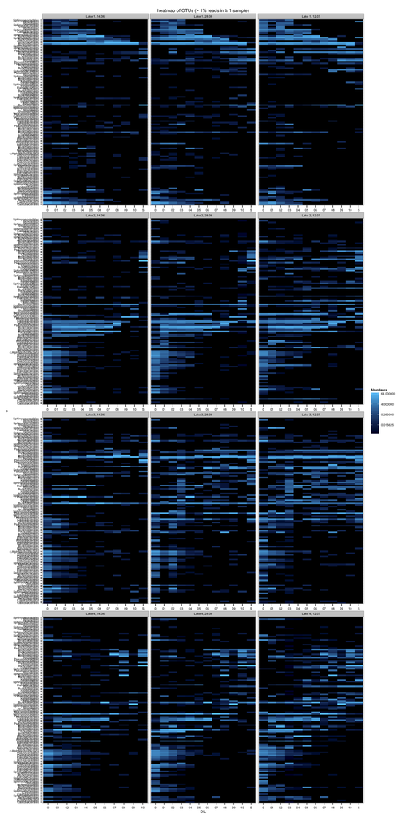

To get a clearer picture of the differences between the lakes, we look at the average abundance of each OTU, over the three sampling dates.

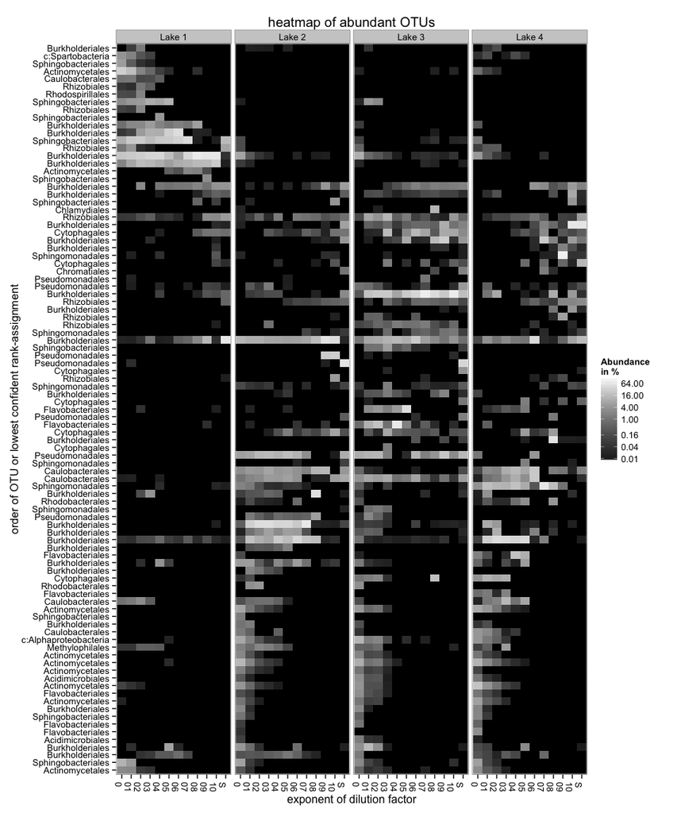